# Risk Factor Analysis

## Outcome Variable

**Outcome Variable:** pers_wasted624

## Predictor Variables

**Intervention Variable:** pers_wasted06

**Adjustment Set:**

- sex
- arm
- enstunt
- month
- brthmon
- vagbrth
- single
- W_gagebrth
- W_birthwt
- W_birthlen
- W_mage
- W_mhtcm
- W_meducyrs
- W_feducyrs
- W_parity
- delta_month
- delta_brthmon
- delta_vagbrth
- delta_single
- delta_W_gagebrth
- delta_W_birthwt
- delta_W_birthlen
- delta_W_mage
- delta_W_mhtcm
- delta_W_meducyrs
- delta_W_feducyrs
- delta_W_parity

## Stratifying Variables

The analysis was stratified on these variable(s):

- studyid
- country

## Data Summary

| studyid | country | pers_wasted06 | pers_wasted624 | n_cell | n |
| --- | --- | --- | --- | --- | --- |
| ki0047075b-MAL-ED | BANGLADESH | 0 | 0 | 218 | 240 |
| ki0047075b-MAL-ED | BANGLADESH | 0 | 1 | 15 | 240 |
| ki0047075b-MAL-ED | BANGLADESH | 1 | 0 | 4 | 240 |
| ki0047075b-MAL-ED | BANGLADESH | 1 | 1 | 3 | 240 |
| ki0047075b-MAL-ED | BRAZIL | 0 | 0 | 205 | 207 |
| ki0047075b-MAL-ED | BRAZIL | 0 | 1 | 1 | 207 |
| ki0047075b-MAL-ED | BRAZIL | 1 | 0 | 0 | 207 |
| ki0047075b-MAL-ED | BRAZIL | 1 | 1 | 1 | 207 |
| ki0047075b-MAL-ED | INDIA | 0 | 0 | 201 | 235 |
| ki0047075b-MAL-ED | INDIA | 0 | 1 | 18 | 235 |
| ki0047075b-MAL-ED | INDIA | 1 | 0 | 6 | 235 |
| ki0047075b-MAL-ED | INDIA | 1 | 1 | 10 | 235 |
| ki0047075b-MAL-ED | NEPAL | 0 | 0 | 231 | 235 |
| ki0047075b-MAL-ED | NEPAL | 0 | 1 | 0 | 235 |
| ki0047075b-MAL-ED | NEPAL | 1 | 0 | 2 | 235 |
| ki0047075b-MAL-ED | NEPAL | 1 | 1 | 2 | 235 |
| ki0047075b-MAL-ED | PERU | 0 | 0 | 268 | 270 |
| ki0047075b-MAL-ED | PERU | 0 | 1 | 2 | 270 |
| ki0047075b-MAL-ED | PERU | 1 | 0 | 0 | 270 |
| ki0047075b-MAL-ED | PERU | 1 | 1 | 0 | 270 |
| ki0047075b-MAL-ED | SOUTH AFRICA | 0 | 0 | 256 | 259 |
| ki0047075b-MAL-ED | SOUTH AFRICA | 0 | 1 | 1 | 259 |
| ki0047075b-MAL-ED | SOUTH AFRICA | 1 | 0 | 1 | 259 |
| ki0047075b-MAL-ED | SOUTH AFRICA | 1 | 1 | 1 | 259 |
| ki0047075b-MAL-ED | TANZANIA, UNITED REPUBLIC OF | 0 | 0 | 245 | 245 |
| ki0047075b-MAL-ED | TANZANIA, UNITED REPUBLIC OF | 0 | 1 | 0 | 245 |
| ki0047075b-MAL-ED | TANZANIA, UNITED REPUBLIC OF | 1 | 0 | 0 | 245 |
| ki0047075b-MAL-ED | TANZANIA, UNITED REPUBLIC OF | 1 | 1 | 0 | 245 |
| ki1000108-CMC-V-BCS-2002 | INDIA | 0 | 0 | 307 | 370 |
| ki1000108-CMC-V-BCS-2002 | INDIA | 0 | 1 | 11 | 370 |

[output cut: 102 more lines]

The following strata were considered:

- studyid: ki0047075b-MAL-ED, country: BANGLADESH
- studyid: ki0047075b-MAL-ED, country: BRAZIL
- studyid: ki0047075b-MAL-ED, country: INDIA
- studyid: ki0047075b-MAL-ED, country: NEPAL
- studyid: ki0047075b-MAL-ED, country: PERU
- studyid: ki0047075b-MAL-ED, country: SOUTH AFRICA
- studyid: ki0047075b-MAL-ED, country: TANZANIA, UNITED REPUBLIC OF
- studyid: ki1000108-CMC-V-BCS-2002, country: INDIA
- studyid: ki1000108-IRC, country: INDIA
- studyid: ki1000109-EE, country: PAKISTAN
- studyid: ki1000109-ResPak, country: PAKISTAN
- studyid: ki1000304b-SAS-CompFeed, country: INDIA
- studyid: ki1000304b-SAS-FoodSuppl, country: INDIA
- studyid: ki1017093-NIH-Birth, country: BANGLADESH
- studyid: ki1017093b-PROVIDE, country: BANGLADESH
- studyid: ki1017093c-NIH-Crypto, country: BANGLADESH
- studyid: ki1066203-TanzaniaChild2, country: TANZANIA, UNITED REPUBLIC OF
- studyid: ki1101329-Keneba, country: GAMBIA
- studyid: ki1112895-Guatemala BSC, country: GUATEMALA
- studyid: ki1113344-GMS-Nepal, country: NEPAL
- studyid: ki1114097-CMIN, country: BANGLADESH
- studyid: ki1114097-CMIN, country: BRAZIL
- studyid: ki1114097-CMIN, country: GUINEA-BISSAU
- studyid: ki1114097-CMIN, country: PERU
- studyid: ki1114097-CONTENT, country: PERU
- studyid: ki1119695-PROBIT, country: BELARUS
- studyid: ki1126311-ZVITAMBO, country: ZIMBABWE
- studyid: ki1135781-COHORTS, country: GUATEMALA
- studyid: ki1135781-COHORTS, country: INDIA
- studyid: ki1135781-COHORTS, country: PHILIPPINES
- studyid: ki1148112-LCNI-5, country: MALAWI
- studyid: kiGH5241-JiVitA-3, country: BANGLADESH
- studyid: kiGH5241-JiVitA-4, country: BANGLADESH

### Dropped Strata

Some strata were dropped due to rare outcomes:

- studyid: ki0047075b-MAL-ED, country: BANGLADESH
- studyid: ki0047075b-MAL-ED, country: BRAZIL
- studyid: ki0047075b-MAL-ED, country: NEPAL
- studyid: ki0047075b-MAL-ED, country: PERU
- studyid: ki0047075b-MAL-ED, country: SOUTH AFRICA
- studyid: ki0047075b-MAL-ED, country: TANZANIA, UNITED REPUBLIC OF
- studyid: ki1112895-Guatemala BSC, country: GUATEMALA
- studyid: ki1114097-CMIN, country: BANGLADESH
- studyid: ki1114097-CMIN, country: BRAZIL
- studyid: ki1114097-CMIN, country: PERU
- studyid: ki1114097-CONTENT, country: PERU

## Methods Detail

We’re interested in the causal parameters $E[Y_a]$ for all values of $a \in \mathcal{A}$. These parameters represent the mean outcome if, possibly contrary to fact, we intervened to set all units to have $A=a$. Under the randomization and positivity assumptions, these are identified by the statistical parameters $\psi_a=E_W[E_{Y|A,W}(Y|A=a,W)]$. In addition, we’re interested in the mean of $Y$, $E[Y]$ under no intervention (the observed mean). We will estimate these parameters by using SuperLearner to fit the relevant likelihood factors – $E_{Y|A,W}(Y|A=a,W)$ and $p(A=a|W)$, and then updating our likelihood fit using a joint TMLE.

For unadjusted analyses ($W=\{\}$), initial likelihoods were estimated using Lrnr_glm to estimate the simple $E(Y|A)$ and Lrnr_mean to estimate $p(A)$. For adjusted analyses, a small library containing Lrnr_glmnet, Lrnr_xgboost, and Lrnr_mean was used.

Having estimated these parameters, we will then use the delta method to estimate relative risks and attributable risks relative to a prespecified baseline level of $A$.

# Results Detail

## Results Plots

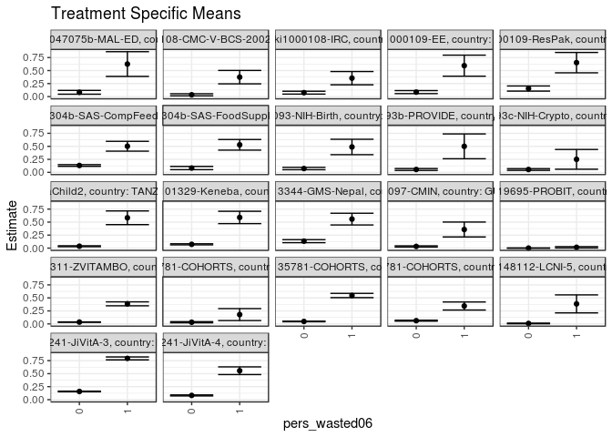

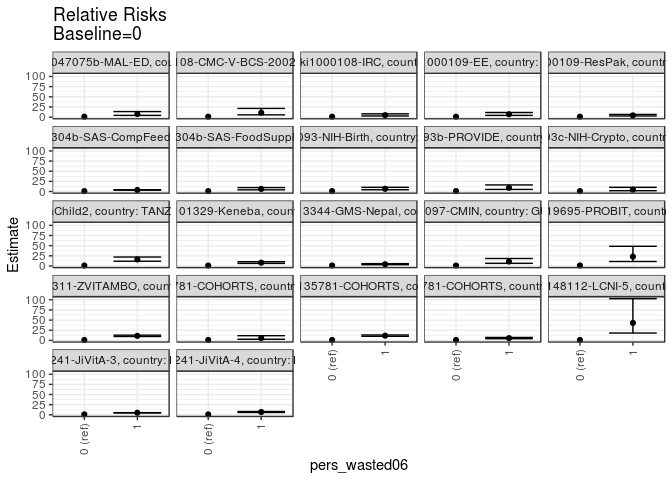

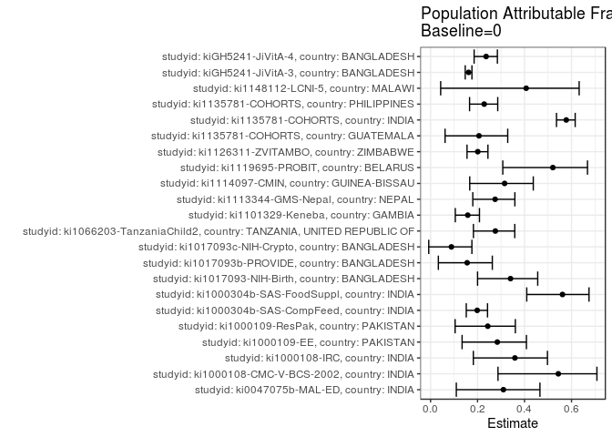

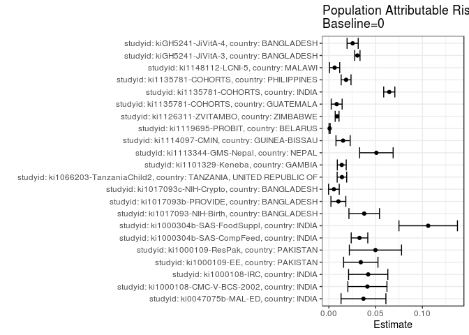

## Results Table

### Parameter: TSM

| studyid | country | intervention_level | baseline_level | estimate | ci_lower | ci_upper |
| --- | --- | --- | --- | --- | --- | --- |
| ki0047075b-MAL-ED | INDIA | 0 | NA | 0.0821918 | 0.0457380 | 0.1186455 |
| ki0047075b-MAL-ED | INDIA | 1 | NA | 0.6250000 | 0.3872778 | 0.8627222 |
| ki1000108-CMC-V-BCS-2002 | INDIA | 0 | NA | 0.0345154 | 0.0144420 | 0.0545888 |
| ki1000108-CMC-V-BCS-2002 | INDIA | 1 | NA | 0.3735727 | 0.2444754 | 0.5026699 |
| ki1000108-IRC | INDIA | 0 | NA | 0.0750459 | 0.0473369 | 0.1027550 |
| ki1000108-IRC | INDIA | 1 | NA | 0.3539826 | 0.2264648 | 0.4815004 |
| ki1000109-EE | PAKISTAN | 0 | NA | 0.0859044 | 0.0564849 | 0.1153239 |
| ki1000109-EE | PAKISTAN | 1 | NA | 0.5940614 | 0.3916792 | 0.7964436 |
| ki1000109-ResPak | PAKISTAN | 0 | NA | 0.1545894 | 0.1052342 | 0.2039446 |
| ki1000109-ResPak | PAKISTAN | 1 | NA | 0.6521739 | 0.4571027 | 0.8472451 |
| ki1000304b-SAS-CompFeed | INDIA | 0 | NA | 0.1320366 | 0.1155662 | 0.1485069 |
| ki1000304b-SAS-CompFeed | INDIA | 1 | NA | 0.5018650 | 0.4073634 | 0.5963665 |
| ki1000304b-SAS-FoodSuppl | INDIA | 0 | NA | 0.0828868 | 0.0518173 | 0.1139563 |
| ki1000304b-SAS-FoodSuppl | INDIA | 1 | NA | 0.5290346 | 0.4268093 | 0.6312599 |
| ki1017093-NIH-Birth | BANGLADESH | 0 | NA | 0.0731522 | 0.0501182 | 0.0961862 |
| ki1017093-NIH-Birth | BANGLADESH | 1 | NA | 0.4878642 | 0.3399515 | 0.6357769 |
| ki1017093b-PROVIDE | BANGLADESH | 0 | NA | 0.0549085 | 0.0366394 | 0.0731775 |
| ki1017093b-PROVIDE | BANGLADESH | 1 | NA | 0.5000000 | 0.2613176 | 0.7386824 |
| ki1017093c-NIH-Crypto | BANGLADESH | 0 | NA | 0.0549296 | 0.0381589 | 0.0717003 |
| ki1017093c-NIH-Crypto | BANGLADESH | 1 | NA | 0.2500000 | 0.0600972 | 0.4399028 |
| ki1066203-TanzaniaChild2 | TANZANIA, UNITED REPUBLIC OF | 0 | NA | 0.0366067 | 0.0282871 | 0.0449263 |
| ki1066203-TanzaniaChild2 | TANZANIA, UNITED REPUBLIC OF | 1 | NA | 0.5829114 | 0.4514302 | 0.7143926 |
| ki1101329-Keneba | GAMBIA | 0 | NA | 0.0730448 | 0.0621820 | 0.0839076 |
| ki1101329-Keneba | GAMBIA | 1 | NA | 0.5893420 | 0.4706528 | 0.7080313 |
| ki1113344-GMS-Nepal | NEPAL | 0 | NA | 0.1339748 | 0.1046916 | 0.1632579 |
| ki1113344-GMS-Nepal | NEPAL | 1 | NA | 0.5578405 | 0.4452536 | 0.6704273 |
| ki1114097-CMIN | GUINEA-BISSAU | 0 | NA | 0.0329290 | 0.0217238 | 0.0441342 |
| ki1114097-CMIN | GUINEA-BISSAU | 1 | NA | 0.3578612 | 0.2145849 | 0.5011376 |
| ki1119695-PROBIT | BELARUS | 0 | NA | 0.0006934 | 0.0001312 | 0.0012555 |
| ki1119695-PROBIT | BELARUS | 1 | NA | 0.0159946 | 0.0031495 | 0.0288397 |
| ki1126311-ZVITAMBO | ZIMBABWE | 0 | NA | 0.0348594 | 0.0311109 | 0.0386078 |
| ki1126311-ZVITAMBO | ZIMBABWE | 1 | NA | 0.3855399 | 0.3478870 | 0.4231929 |
| ki1135781-COHORTS | GUATEMALA | 0 | NA | 0.0320011 | 0.0208711 | 0.0431312 |
| ki1135781-COHORTS | GUATEMALA | 1 | NA | 0.1791057 | 0.0639261 | 0.2942852 |
| ki1135781-COHORTS | INDIA | 0 | NA | 0.0471800 | 0.0415599 | 0.0528002 |
| ki1135781-COHORTS | INDIA | 1 | NA | 0.5458194 | 0.5044844 | 0.5871544 |
| ki1135781-COHORTS | PHILIPPINES | 0 | NA | 0.0621099 | 0.0528146 | 0.0714052 |
| ki1135781-COHORTS | PHILIPPINES | 1 | NA | 0.3439694 | 0.2668385 | 0.4211004 |
| ki1148112-LCNI-5 | MALAWI | 0 | NA | 0.0089286 | 0.0022811 | 0.0155761 |
| ki1148112-LCNI-5 | MALAWI | 1 | NA | 0.3846154 | 0.2119598 | 0.5572710 |
| kiGH5241-JiVitA-3 | BANGLADESH | 0 | NA | 0.1575669 | 0.1513109 | 0.1638230 |
| kiGH5241-JiVitA-3 | BANGLADESH | 1 | NA | 0.7932404 | 0.7654104 | 0.8210703 |
| kiGH5241-JiVitA-4 | BANGLADESH | 0 | NA | 0.0818986 | 0.0724551 | 0.0913420 |
| kiGH5241-JiVitA-4 | BANGLADESH | 1 | NA | 0.5564993 | 0.4823647 | 0.6306339 |

### Parameter: E(Y)

| studyid | country | intervention_level | baseline_level | estimate | ci_lower | ci_upper |
| --- | --- | --- | --- | --- | --- | --- |
| ki0047075b-MAL-ED | INDIA | NA | NA | 0.1191489 | 0.0776405 | 0.1606574 |
| ki1000108-CMC-V-BCS-2002 | INDIA | NA | NA | 0.0756757 | 0.0486905 | 0.1026609 |
| ki1000108-IRC | INDIA | NA | NA | 0.1170732 | 0.0859146 | 0.1482317 |
| ki1000109-EE | PAKISTAN | NA | NA | 0.1200000 | 0.0870660 | 0.1529340 |
| ki1000109-ResPak | PAKISTAN | NA | NA | 0.2043478 | 0.1521230 | 0.2565727 |
| ki1000304b-SAS-CompFeed | INDIA | NA | NA | 0.1647399 | 0.1451050 | 0.1843747 |
| ki1000304b-SAS-FoodSuppl | INDIA | NA | NA | 0.1890547 | 0.1507312 | 0.2273783 |
| ki1017093-NIH-Birth | BANGLADESH | NA | NA | 0.1109057 | 0.0844206 | 0.1373909 |
| ki1017093b-PROVIDE | BANGLADESH | NA | NA | 0.0650407 | 0.0455353 | 0.0845460 |
| ki1017093c-NIH-Crypto | BANGLADESH | NA | NA | 0.0602740 | 0.0429977 | 0.0775502 |
| ki1066203-TanzaniaChild2 | TANZANIA, UNITED REPUBLIC OF | NA | NA | 0.0505451 | 0.0409848 | 0.0601054 |
| ki1101329-Keneba | GAMBIA | NA | NA | 0.0867841 | 0.0752007 | 0.0983676 |
| ki1113344-GMS-Nepal | NEPAL | NA | NA | 0.1847458 | 0.1534039 | 0.2160876 |
| ki1114097-CMIN | GUINEA-BISSAU | NA | NA | 0.0480864 | 0.0349437 | 0.0612290 |
| ki1119695-PROBIT | BELARUS | NA | NA | 0.0014461 | 0.0004206 | 0.0024716 |
| ki1126311-ZVITAMBO | ZIMBABWE | NA | NA | 0.0436257 | 0.0397395 | 0.0475120 |
| ki1135781-COHORTS | GUATEMALA | NA | NA | 0.0403147 | 0.0282199 | 0.0524094 |
| ki1135781-COHORTS | INDIA | NA | NA | 0.1117237 | 0.1042858 | 0.1191617 |
| ki1135781-COHORTS | PHILIPPINES | NA | NA | 0.0804843 | 0.0704205 | 0.0905481 |
| ki1148112-LCNI-5 | MALAWI | NA | NA | 0.0150565 | 0.0065967 | 0.0235162 |
| kiGH5241-JiVitA-3 | BANGLADESH | NA | NA | 0.1880070 | 0.1814627 | 0.1945512 |
| kiGH5241-JiVitA-4 | BANGLADESH | NA | NA | 0.1072724 | 0.0967392 | 0.1178055 |

### Parameter: RR

| studyid | country | intervention_level | baseline_level | estimate | ci_lower | ci_upper |
| --- | --- | --- | --- | --- | --- | --- |
| ki0047075b-MAL-ED | INDIA | 0 | 0 | 1.000000 | 1.000000 | 1.000000 |
| ki0047075b-MAL-ED | INDIA | 1 | 0 | 7.604167 | 4.239385 | 13.639560 |
| ki1000108-CMC-V-BCS-2002 | INDIA | 0 | 0 | 1.000000 | 1.000000 | 1.000000 |
| ki1000108-CMC-V-BCS-2002 | INDIA | 1 | 0 | 10.823354 | 5.494796 | 21.319264 |
| ki1000108-IRC | INDIA | 0 | 0 | 1.000000 | 1.000000 | 1.000000 |
| ki1000108-IRC | INDIA | 1 | 0 | 4.716879 | 2.811519 | 7.913496 |
| ki1000109-EE | PAKISTAN | 0 | 0 | 1.000000 | 1.000000 | 1.000000 |
| ki1000109-EE | PAKISTAN | 1 | 0 | 6.915380 | 4.263356 | 11.217100 |
| ki1000109-ResPak | PAKISTAN | 0 | 0 | 1.000000 | 1.000000 | 1.000000 |
| ki1000109-ResPak | PAKISTAN | 1 | 0 | 4.218750 | 2.723858 | 6.534061 |
| ki1000304b-SAS-CompFeed | INDIA | 0 | 0 | 1.000000 | 1.000000 | 1.000000 |
| ki1000304b-SAS-CompFeed | INDIA | 1 | 0 | 3.800955 | 3.293688 | 4.386346 |
| ki1000304b-SAS-FoodSuppl | INDIA | 0 | 0 | 1.000000 | 1.000000 | 1.000000 |
| ki1000304b-SAS-FoodSuppl | INDIA | 1 | 0 | 6.382618 | 4.185015 | 9.734209 |
| ki1017093-NIH-Birth | BANGLADESH | 0 | 0 | 1.000000 | 1.000000 | 1.000000 |
| ki1017093-NIH-Birth | BANGLADESH | 1 | 0 | 6.669168 | 4.308018 | 10.324422 |
| ki1017093b-PROVIDE | BANGLADESH | 0 | 0 | 1.000000 | 1.000000 | 1.000000 |
| ki1017093b-PROVIDE | BANGLADESH | 1 | 0 | 9.106061 | 5.088919 | 16.294295 |
| ki1017093c-NIH-Crypto | BANGLADESH | 0 | 0 | 1.000000 | 1.000000 | 1.000000 |
| ki1017093c-NIH-Crypto | BANGLADESH | 1 | 0 | 4.551282 | 2.007191 | 10.319981 |
| ki1066203-TanzaniaChild2 | TANZANIA, UNITED REPUBLIC OF | 0 | 0 | 1.000000 | 1.000000 | 1.000000 |
| ki1066203-TanzaniaChild2 | TANZANIA, UNITED REPUBLIC OF | 1 | 0 | 15.923610 | 11.559963 | 21.934442 |
| ki1101329-Keneba | GAMBIA | 0 | 0 | 1.000000 | 1.000000 | 1.000000 |
| ki1101329-Keneba | GAMBIA | 1 | 0 | 8.068226 | 6.281474 | 10.363216 |
| ki1113344-GMS-Nepal | NEPAL | 0 | 0 | 1.000000 | 1.000000 | 1.000000 |
| ki1113344-GMS-Nepal | NEPAL | 1 | 0 | 4.163773 | 3.099386 | 5.593690 |
| ki1114097-CMIN | GUINEA-BISSAU | 0 | 0 | 1.000000 | 1.000000 | 1.000000 |
| ki1114097-CMIN | GUINEA-BISSAU | 1 | 0 | 10.867667 | 6.430862 | 18.365529 |
| ki1119695-PROBIT | BELARUS | 0 | 0 | 1.000000 | 1.000000 | 1.000000 |
| ki1119695-PROBIT | BELARUS | 1 | 0 | 23.068075 | 10.989824 | 48.420803 |
| ki1126311-ZVITAMBO | ZIMBABWE | 0 | 0 | 1.000000 | 1.000000 | 1.000000 |
| ki1126311-ZVITAMBO | ZIMBABWE | 1 | 0 | 11.059870 | 9.565214 | 12.788081 |
| ki1135781-COHORTS | GUATEMALA | 0 | 0 | 1.000000 | 1.000000 | 1.000000 |
| ki1135781-COHORTS | GUATEMALA | 1 | 0 | 5.596851 | 2.706880 | 11.572268 |
| ki1135781-COHORTS | INDIA | 0 | 0 | 1.000000 | 1.000000 | 1.000000 |
| ki1135781-COHORTS | INDIA | 1 | 0 | 11.568862 | 10.051923 | 13.314724 |
| ki1135781-COHORTS | PHILIPPINES | 0 | 0 | 1.000000 | 1.000000 | 1.000000 |
| ki1135781-COHORTS | PHILIPPINES | 1 | 0 | 5.538075 | 4.235628 | 7.241022 |
| ki1148112-LCNI-5 | MALAWI | 0 | 0 | 1.000000 | 1.000000 | 1.000000 |
| ki1148112-LCNI-5 | MALAWI | 1 | 0 | 43.076923 | 18.058272 | 102.757410 |
| kiGH5241-JiVitA-3 | BANGLADESH | 0 | 0 | 1.000000 | 1.000000 | 1.000000 |
| kiGH5241-JiVitA-3 | BANGLADESH | 1 | 0 | 5.034307 | 4.783049 | 5.298763 |
| kiGH5241-JiVitA-4 | BANGLADESH | 0 | 0 | 1.000000 | 1.000000 | 1.000000 |
| kiGH5241-JiVitA-4 | BANGLADESH | 1 | 0 | 6.794983 | 5.697591 | 8.103740 |

### Parameter: PAR

| studyid | country | intervention_level | baseline_level | estimate | ci_lower | ci_upper |
| --- | --- | --- | --- | --- | --- | --- |
| ki0047075b-MAL-ED | INDIA | 0 | NA | 0.0369572 | 0.0129774 | 0.0609369 |
| ki1000108-CMC-V-BCS-2002 | INDIA | 0 | NA | 0.0411603 | 0.0202615 | 0.0620590 |
| ki1000108-IRC | INDIA | 0 | NA | 0.0420272 | 0.0210457 | 0.0630088 |
| ki1000109-EE | PAKISTAN | 0 | NA | 0.0340956 | 0.0157296 | 0.0524616 |
| ki1000109-ResPak | PAKISTAN | 0 | NA | 0.0497585 | 0.0218535 | 0.0776634 |
| ki1000304b-SAS-CompFeed | INDIA | 0 | NA | 0.0327033 | 0.0238373 | 0.0415693 |
| ki1000304b-SAS-FoodSuppl | INDIA | 0 | NA | 0.1061679 | 0.0748939 | 0.1374420 |
| ki1017093-NIH-Birth | BANGLADESH | 0 | NA | 0.0377535 | 0.0214203 | 0.0540868 |
| ki1017093b-PROVIDE | BANGLADESH | 0 | NA | 0.0101322 | 0.0021706 | 0.0180938 |
| ki1017093c-NIH-Crypto | BANGLADESH | 0 | NA | 0.0053444 | -0.0003673 | 0.0110561 |
| ki1066203-TanzaniaChild2 | TANZANIA, UNITED REPUBLIC OF | 0 | NA | 0.0139384 | 0.0088366 | 0.0190401 |
| ki1101329-Keneba | GAMBIA | 0 | NA | 0.0137393 | 0.0089768 | 0.0185018 |
| ki1113344-GMS-Nepal | NEPAL | 0 | NA | 0.0507710 | 0.0328711 | 0.0686709 |
| ki1114097-CMIN | GUINEA-BISSAU | 0 | NA | 0.0151574 | 0.0075644 | 0.0227504 |
| ki1119695-PROBIT | BELARUS | 0 | NA | 0.0007528 | 0.0001698 | 0.0013358 |
| ki1126311-ZVITAMBO | ZIMBABWE | 0 | NA | 0.0087664 | 0.0067144 | 0.0108184 |
| ki1135781-COHORTS | GUATEMALA | 0 | NA | 0.0083135 | 0.0024768 | 0.0141502 |
| ki1135781-COHORTS | INDIA | 0 | NA | 0.0645437 | 0.0585924 | 0.0704950 |
| ki1135781-COHORTS | PHILIPPINES | 0 | NA | 0.0183744 | 0.0131143 | 0.0236346 |
| ki1148112-LCNI-5 | MALAWI | 0 | NA | 0.0061279 | 0.0006884 | 0.0115674 |
| kiGH5241-JiVitA-3 | BANGLADESH | 0 | NA | 0.0304400 | 0.0276167 | 0.0332633 |
| kiGH5241-JiVitA-4 | BANGLADESH | 0 | NA | 0.0253738 | 0.0194169 | 0.0313308 |

### Parameter: PAF

| studyid | country | intervention_level | baseline_level | estimate | ci_lower | ci_upper |
| --- | --- | --- | --- | --- | --- | --- |
| ki0047075b-MAL-ED | INDIA | 0 | NA | 0.3101761 | 0.1095701 | 0.4655873 |
| ki1000108-CMC-V-BCS-2002 | INDIA | 0 | NA | 0.5439033 | 0.2870531 | 0.7082193 |
| ki1000108-IRC | INDIA | 0 | NA | 0.3589826 | 0.1821066 | 0.4976077 |
| ki1000109-EE | PAKISTAN | 0 | NA | 0.2841302 | 0.1342216 | 0.4080823 |
| ki1000109-ResPak | PAKISTAN | 0 | NA | 0.2434988 | 0.1045154 | 0.3609113 |
| ki1000304b-SAS-CompFeed | INDIA | 0 | NA | 0.1985149 | 0.1519871 | 0.2424899 |
| ki1000304b-SAS-FoodSuppl | INDIA | 0 | NA | 0.5615726 | 0.4094834 | 0.6744907 |
| ki1017093-NIH-Birth | BANGLADESH | 0 | NA | 0.3404111 | 0.2000953 | 0.4561133 |
| ki1017093b-PROVIDE | BANGLADESH | 0 | NA | 0.1557820 | 0.0331417 | 0.2628662 |
| ki1017093c-NIH-Crypto | BANGLADESH | 0 | NA | 0.0886684 | -0.0078075 | 0.1759087 |
| ki1066203-TanzaniaChild2 | TANZANIA, UNITED REPUBLIC OF | 0 | NA | 0.2757608 | 0.1824458 | 0.3584250 |
| ki1101329-Keneba | GAMBIA | 0 | NA | 0.1583162 | 0.1053212 | 0.2081720 |
| ki1113344-GMS-Nepal | NEPAL | 0 | NA | 0.2748155 | 0.1797722 | 0.3588458 |
| ki1114097-CMIN | GUINEA-BISSAU | 0 | NA | 0.3152115 | 0.1667058 | 0.4372513 |
| ki1119695-PROBIT | BELARUS | 0 | NA | 0.5205385 | 0.3074884 | 0.6680440 |
| ki1126311-ZVITAMBO | ZIMBABWE | 0 | NA | 0.2009453 | 0.1552191 | 0.2441964 |
| ki1135781-COHORTS | GUATEMALA | 0 | NA | 0.2062154 | 0.0617170 | 0.3284607 |
| ki1135781-COHORTS | INDIA | 0 | NA | 0.5777080 | 0.5360437 | 0.6156307 |
| ki1135781-COHORTS | PHILIPPINES | 0 | NA | 0.2282980 | 0.1660225 | 0.2859231 |
| ki1148112-LCNI-5 | MALAWI | 0 | NA | 0.4069940 | 0.0430324 | 0.6325309 |
| kiGH5241-JiVitA-3 | BANGLADESH | 0 | NA | 0.1619089 | 0.1475086 | 0.1760661 |
| kiGH5241-JiVitA-4 | BANGLADESH | 0 | NA | 0.2365364 | 0.1854391 | 0.2844284 |